# jsc270_tut2-answers_moon_999999999

**A FEW NOTES ON SUBMISSIONS**

- When presenting answers for tutorial questions, feel free to use bullet points and tables. It helps with readability. This cell has bullet points and a sample table below written in markdown.

| col1 | col2 | col3 | col4 |
| --- | --- | --- | --- |
| a | b | c | d |
| 1 | 2 | 3 | 4 |

- When presenting numerical outputs from code blocks, please remove excessive decimals. Keep the values to 2~3 decimal places.
- When drawing multiple plots, try to use subplots and place them in one view as appropriate.
- When choosing the types of plots, see sample plots from class as well as online. Avoid using pie charts in general. They often don't show differences between categories clearly.
- Use colors with visualizations - colors can give your plot a 3rd dimension.
- For the last question on $\chi^2$ test, please see the sample answer for the list of assumptions on validity.
- You don't need load a library multiple times. If you loaded a library in a cell, you can use the library in the following cells just like variables.
- Get familiar with string manipulation methods and regex. It can save you many lines of codes.

Below are some sample answers.

# JSC270S - Tutorial #2 : Influenza Survelliance in Canada

## Profs. F. Chevalier and N. Taback

## Date: January 23, 2019

## Time: 12:00 - 14:00

## Location: BA 3175

## Instructions

- Make a copy of this notebook.
- The notebook should be named: jsc270_tut1_answers_lastname_studentnumber, where "lastname" is your last name, and "studentnumber" is your UofT student number.
- Answer the questions in the cells that indicate where your answers should be placed. Leave the initial comment in the code cell and heading (indicated by `# Answer for qustion XX`). For example, place your code for Question 1 in the code cell with comment `# Enter your answer for Question 1 into this cell` (remember not to delete this comment).
- Make sure that you explain your solutions when asked and comment your code.
- Commit and push changes to the Github classroom repository that we has been provided (more details below).

### What should be submitted?

- A *Jupyter notebook* using Python that contains all the data analyses. Make sure to comment your code in the code cells.
- Additional files that your notebook requires to compile properly (e.g. a data file).
- A pdf of your Jupyter notebook exported as a pdf file. This can be done using [`nbconvert`](https://nbconvert.readthedocs.io/en/latest/install.html).

### When should it be submitted?

*This tutorial consists of a 2-step submission as follows:*

- **At the end of the tutorial (in-lab tutorial assignment)**: Commit and push your notebook to the Github classroom repository that contains your answers (i.e., the file named: jsc270_tut1_answers_lastname_studentnumber.ipynb) before 14:10 on the day of the tutorial, January 23.
- In between January 23, 14:10 p.m. and January 28, 11:30 you should commit and push your answer notebook as you work on the assignment during the week. Commiting and pushing often is good practice (and as a bonus you will have a backup and be able to revisit previous version).
- [`nbdime`](https://nbdime.readthedocs.io/en/latest/) is a Python package that allows you (and the teaching team) to the changes you have made to your assignment.
- **Homework (tutorial assignment completion)**: Push your completed tutorial by 11:30, Monday, January 28. Your last commit closest to 11:30 will be considered your final assignment.

### Where should the assignment be submitted?

Push your finished notebook and any other files on Github, through the following link: https://classroom.github.com/a/gH0AsH-r

Upload the pdf of your answer notebook to the JSC270 course page on Quercus.

## Tutorial Grading

Tutorials will be graded according to the following marking scheme.

|  | Marks |
| --- | --- |
| Tutorial Participation | 5 |
| Attendance for entire tutorial | 5 |
| In-lab tutorial assignment | 20 |
| Tutorial assignment completion | 20 |

### Grading Rubric for Tutorial Assignments

Tutorial grading rubric is available [here](https://jsc270.github.io/tut_docs.html#tutorial_grading).

## Tutorial objectives

The goal of this tutorial is to explore questions related to the distribution of influenza in Canada.

[FluWatch](https://www.canada.ca/en/public-health/services/diseases/flu-influenza/influenza-surveillance.html) is Canada's national surveillance system that monitors the spread of flu and flu-like illnesses. The [Respiratory Virus Report, Week 01 ending January 5, 2019 contains respiratory virus detections/isolations fro the period August 26, 2018 - January 5, 2019](https://www.canada.ca/en/public-health/services/surveillance/respiratory-virus-detections-canada/2018-2019/respiratory-virus-detections-isolations-week-01-ending-january-5-2019.html) in Table 2.

# Question 1

(a) Write a Python program to scrape (read in) the data in [Table 2](https://www.canada.ca/en/public-health/services/surveillance/respiratory-virus-detections-canada/2018-2019/respiratory-virus-detections-isolations-week-01-ending-january-5-2019.html) into a pandas data frame. Use the table to create a dataframe that contains one row for each province or territory.

```python
# code for question 1 (a)
import pandas as pd

# url for the report page
# + break lines with '\' when the code line is not ecapsulated
#   in any brackets/parentheses
# + make the lines readable by keeping the width reasonable
#   and aligning them with tabs (4 spaces)
report_page = 'https://www.canada.ca/en/public-health/services/' + \
    'surveillance/respiratory-virus-detections-canada/' + \
    '2018-2019/respiratory-virus-detections-isolations-' + \
    'week-01-ending-january-5-2019.html'

# using pandas `read_html`
df = pd.read_html(report_page) # returns a list of tables
df[1] # by inspection we see that Table 2 is the second table

# select. rows corresponding to prov and territory
# + when the code line is within brackets/parentheses
#   you don't need '\' to break lines
fludat = df[1].iloc[[
    0, 1, 2, 3, 11,
    28, 29, 32, 33, 35,
    36, 37, 38
]]
fludat # print the table
```

|  | Reporting Laboratory | Flu Tested | A(H1N1)pdm09 Positive | A(H3) Positive | A(UnS) Positive | Total Flu A Positive | Total Flu B Positive | RSV Tested | RSV Positive | PIV Tested | ... | PIV 4 Positive | Other PIV Positive | Adeno Tested | Adeno Positive | hMPV Tested | hMPV Positive | Entero/Rhino Tested | Entero/Rhino Positive | Coron Tested | Coron Positive |
| --- | --- | --- | --- | --- | --- | --- | --- | --- | --- | --- | --- | --- | --- | --- | --- | --- | --- | --- | --- | --- | --- |
| 0 | Newfoundland | 1299 | 1.0 | 0.0 | 113.0 | 114.0 | 1.0 | 1299.0 | 91.0 | 1299 | ... | 0 | 0 | 1299 | 12 | 1299 | 8 | 1299 | 200 | N.A. | N.A. |
| 1 | Prince Edward Island | 307 | 38.0 | 0.0 | 0.0 | 38.0 | 0.0 | 305.0 | 5.0 | 53 | ... | 3 | 0 | 48 | 5 | 48 | 0 | 48 | 21 | 48 | 0 |
| 2 | Nova Scotia | 864 | 0.0 | 0.0 | 52.0 | 52.0 | 1.0 | 869.0 | 45.0 | 322 | ... | 1 | 0 | 322 | 0 | 322 | 3 | 322 | 53 | 322 | 1 |
| 3 | New Brunswick | 4271 | 42.0 | 1.0 | 715.0 | 758.0 | 2.0 | 4274.0 | 131.0 | 1185 | ... | 29 | 0 | 1185 | 84 | 1185 | 7 | 1185 | 201 | 1185 | 6 |
| 11 | Province of Québec | 38395 | 0.0 | 0.0 | 5974.0 | 5975.0 | 81.0 | 35755.0 | 2816.0 | 11201 | ... | 36 | 0 | 11288 | 373 | 10786 | 63 | N.A. | N.A. | 10703 | 310 |
| 28 | Province of Ontario | 23795 | 752.0 | 180.0 | 546.0 | 1478.0 | 42.0 | 23518.0 | 1123.0 | 13600 | ... | 38 | 0 | 13348 | 117 | 13307 | 101 | 3652 | 683 | 3080 | 117 |
| 29 | Manitoba | 4911 | 192.0 | 3.0 | 486.0 | 681.0 | 3.0 | 4828.0 | 101.0 | 2254 | ... | 10 | 0 | 2254 | 25 | 1214 | 9 | 2254 | 310 | 1248 | 12 |
| 32 | Province of Saskatchewan | 8391 | 1280.0 | 60.0 | 749.0 | 2089.0 | 3.0 | 8391.0 | 160.0 | 10324 | ... | 40 | 0 | 8391 | 106 | 8391 | 47 | 8391 | 1337 | 8391 | 30 |
| 33 | Province of Alberta | 18824 | 3132.0 | 73.0 | 1540.0 | 4745.0 | 29.0 | 15040.0 | 0.0 | 15040 | ... | 154 | 0 | 15040 | 184 | 15040 | 189 | 15040 | 2693 | 15040 | 321 |
| 35 | British Columbia | 8731 | 1010.0 | 75.0 | 755.0 | 1840.0 | 10.0 | 8731.0 | 279.0 | 4342 | ... | 66 | 0 | 4342 | 56 | 4342 | 14 | 3442 | 982 | 3442 | 54 |
| 36 | Yukon | 143 | 16.0 | 1.0 | 6.0 | 23.0 | 0.0 | 122.0 | 2.0 | N.A. | ... | N.A. | N.A. | N.A. | N.A. | N.A. | N.A. | N.A. | N.A. | N.A. | N.A. |
| 37 | Northwest Territories | 435 | 138.0 | 2.0 | 0.0 | 140.0 | 0.0 | 432.0 | 0.0 | 432 | ... | 1 | 0 | 432 | 12 | 432 | 2 | 432 | 82 | 432 | 4 |
| 38 | Nunavut | 33 | 8.0 | 0.0 | 0.0 | 8.0 | 0.0 | 33.0 | 0.0 | 33 | ... | 0 | 0 | 33 | 5 | 32 | 0 | 33 | 10 | 32 | 0 |

13 rows × 23 columns

(b) "The geographical regions of Canada are groupings of provinces and territories established for the purpose of statistical reporting" (see [Statistics Canada](https://www150.statcan.gc.ca/n1/pub/92-195-x/2011001/geo/region/region-eng.htm)). Wikipedia has a table with the provinces and territories classified by the six-regions used by Statistics Canada.

(i) Write a Python program to scrape the [table under National regions](https://en.wikipedia.org/wiki/List_of_regions_of_Canada#National_regions) into a pandas dataframe using Python.

(ii) Write Python code to create a data frame that contains two columns: provinces/territories and regions.

(iii) Write Python code that to create another dataframe that contain the following data for each province:

- Flu Tested;
- A(H1N1)pdm09 Positive;
- A(H3) Positive;
- A(UnS) Positive;
- Total Flu A Positive;
- Proportion of Flu A Positive (defined as the ratio of Total Flu A Positive to Flu Tested);
- Geographical region of Canada (using the Statistics Canada definition) (this variable should be added to your data frame using Python code).

NB: The dataframes that you create in this question are often referred to as a **contingency table** in statistics. In general: let $X$ be a categorical random variable that has $I$ levels, and $Y$ a categorical random variable having $J$ levels. A table displaying the $IJ$ possible frequency counts of outcomes is called a *contingency table*.

```python
# code for question 1 (b)
# read wiki page from the web store the table
wiki_page = 'https://en.wikipedia.org/wiki/List_of_regions_of_Canada'
df = pd.read_html(
    wiki_page,
    header=0, # since the html does not tag (<th>)
              # the first row as column,
              # you need to manually specify it
    attrs = {"class":"wikitable"} # when you know specific html attributes
                                  # of the table you want you can specify
                                  # them here for a more specific query
)
# read the six region columns and prov/territories
regions = df[0][[
    'All provinces and territories',
    'Six-region model[1]'
]]

regions = regions.fillna(
    # propogate non-null values forward
    method = 'ffill', axis = 0
).rename(columns={
    # rename columns
    "All provinces and territories": "prov",
    "Six-region model[1]": "region"
}).replace(
    # rename the province name to match the other table
    ['Newfoundland and Labrador'], ['Newfoundland']
)

# Change province names so they match in both data sets
# `regex=True` allows you to use regular expressions
fludat = (
    fludat
    .replace('Province of', '', regex = True)
    .replace('Québec', 'Quebec', regex = True)
    .rename(columns={"Reporting Laboratory": "prov"})
)

# Alberta, Ontario, Quebec, Sask have extra white space in their names so remove
fludat['prov'] = fludat['prov'].str.strip()

# Merge regions with flu data and only keep required columns
fludat1 = pd.merge(
    fludat, regions, on = 'prov'
).iloc[0:,[0,1,2,3,4,5,23]]
# change the data type to float(numeric) instead of object(string)
fludat1['Flu Tested'] = fludat1['Flu Tested'].astype(float)

# create Proportion of Flu A Positive
# (defined as the ratio of Total Flu A Positive to Flu Tested)
fludat1['propfluA'] = fludat1.apply(
    lambda x: x['Total Flu A Positive']/x['Flu Tested'],
    axis=1
)
fludat1.round(3)
```

|  | prov | Flu Tested | A(H1N1)pdm09 Positive | A(H3) Positive | A(UnS) Positive | Total Flu A Positive | region | propfluA |
| --- | --- | --- | --- | --- | --- | --- | --- | --- |
| 0 | Newfoundland | 1299.0 | 1.0 | 0.0 | 113.0 | 114.0 | Atlantic | 0.088 |
| 1 | Prince Edward Island | 307.0 | 38.0 | 0.0 | 0.0 | 38.0 | Atlantic | 0.124 |
| 2 | Nova Scotia | 864.0 | 0.0 | 0.0 | 52.0 | 52.0 | Atlantic | 0.060 |
| 3 | New Brunswick | 4271.0 | 42.0 | 1.0 | 715.0 | 758.0 | Atlantic | 0.177 |
| 4 | Quebec | 38395.0 | 0.0 | 0.0 | 5974.0 | 5975.0 | Quebec | 0.156 |
| 5 | Ontario | 23795.0 | 752.0 | 180.0 | 546.0 | 1478.0 | Ontario | 0.062 |
| 6 | Manitoba | 4911.0 | 192.0 | 3.0 | 486.0 | 681.0 | Prairies | 0.139 |
| 7 | Saskatchewan | 8391.0 | 1280.0 | 60.0 | 749.0 | 2089.0 | Prairies | 0.249 |
| 8 | Alberta | 18824.0 | 3132.0 | 73.0 | 1540.0 | 4745.0 | Prairies | 0.252 |
| 9 | British Columbia | 8731.0 | 1010.0 | 75.0 | 755.0 | 1840.0 | British Columbia | 0.211 |
| 10 | Yukon | 143.0 | 16.0 | 1.0 | 6.0 | 23.0 | Territories | 0.161 |
| 11 | Northwest Territories | 435.0 | 138.0 | 2.0 | 0.0 | 140.0 | Territories | 0.322 |
| 12 | Nunavut | 33.0 | 8.0 | 0.0 | 0.0 | 8.0 | Territories | 0.242 |

A categorical variable is one for which the measurement scale consists of a set of categories. Categorical variables for which levels do not have a natural ordering a called *nominal variables*. Categorical variables that have ordered levels are called *ordinal variables*. Categorical variables that have numerical distances between two levels of the scale are called often called *interval variables*.

Categorical variables can attain a discrete number of values while a continuous variable can attain values that are a subset of the set of real numbers.

(c) Classify the variables in the data frame in Question 1 b as either nominal, ordinal, interval, or continuous. Briefly explain your reasoning.

# Answer for Question 1 (c)

| Variable | Type | Detail |
| --- | --- | --- |
| prov | nominal | Provinces and territories |
| region | nominal | Geographical regions using Statistics Canada definition |
| Flu Tested | interval | Counts of flu tests performed |
| A(H1N1)pdm09 Positive | interval | Count of Influenza A(H1N1)pdm09 positive cases |
| A(H3) Positive | interval | Count of Influenza A(H3N2) positive cases |
| A(Uns) Positive | interval | Count of Influenza A (Unsubtyped) positive cases |
| Total Flu A Positive | interval | Count of all Influenza A positive cases |
| propfluA | continuous | Proportion of Total Flu A Positive to Flu Tested |

# Question 2

(a) Create appropriate numerical summaries and visualizations for each of the variables in the data frame in Question 1 (b)(iii). Briefly describe the distributions of each variable.

```python
# code for question 2 (a)
fludat1.describe().round(3)
```

|  | Flu Tested | A(H1N1)pdm09 Positive | A(H3) Positive | A(UnS) Positive | Total Flu A Positive | propfluA |
| --- | --- | --- | --- | --- | --- | --- |
| count | 13.000 | 13.000 | 13.000 | 13.000 | 13.000 | 13.000 |
| mean | 8492.231 | 508.385 | 30.385 | 841.231 | 1380.077 | 0.172 |
| std | 11722.218 | 900.599 | 53.981 | 1608.639 | 1924.954 | 0.080 |
| min | 33.000 | 0.000 | 0.000 | 0.000 | 8.000 | 0.060 |
| 25% | 435.000 | 8.000 | 0.000 | 6.000 | 52.000 | 0.124 |
| 50% | 4271.000 | 42.000 | 1.000 | 486.000 | 681.000 | 0.161 |
| 75% | 8731.000 | 752.000 | 60.000 | 749.000 | 1840.000 | 0.242 |
| max | 38395.000 | 3132.000 | 180.000 | 5974.000 | 5975.000 | 0.322 |

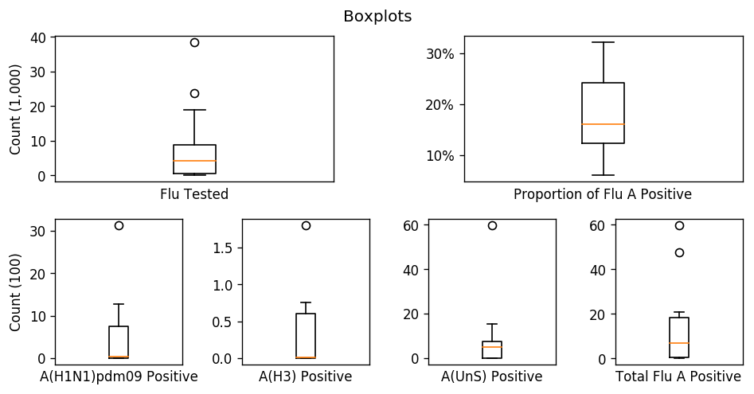

```python
import matplotlib as mpl
import matplotlib.pyplot as plt
from matplotlib.ticker import FuncFormatter
%matplotlib inline

# adjust plot size
fig = plt.figure(
    figsize=(8, 4),
    dpi=120
)

# place flu tested plot in top left of a 2x2 grid
plt.subplot(221)
plt.boxplot(fludat1['Flu Tested']/1000);
plt.ylabel('Count (1,000)')
plt.xlabel('Flu Tested')
plt.xticks([], []) # remove x axis ticks
# place flu proportion plot in top right of the 2x2 grid
ax = plt.subplot(222)
plt.boxplot(fludat1['propfluA']);
# format y tick labels as percentages
# (https://stackoverflow.com/questions/31357611/format-y-axis-as-percent)
ax.yaxis.set_major_formatter(
    FuncFormatter(lambda y, _: '{:.0%}'.format(y))
)
plt.xlabel('Proportion of Flu A Positive')
plt.xticks([], [])

# place boxplotx of positive test counts
# along the bottom of the 2x2 grid
positive_cols = fludat1.columns[2:6]
loc = 245
for ind, col in enumerate(positive_cols):
    plt.subplot(loc + ind)
    plt.xlabel(col)
    plt.ylabel('')
    if ind == 0:
        plt.ylabel('Count (100)')
    plt.boxplot(fludat1[col]/100);
    plt.xticks([], [])

# add a title for all plots
plt.suptitle('Boxplots', va='bottom')
# fit plot to avoid overlapping labels
plt.tight_layout();
```

# Answer for Question 2 (a)

- The counts are heavily skewed toward 0.
- The raw counts have outliers that are extremely large compared to the rest of data.
- The proportion is distributed evenly
- The proportion has no outliers.
- ...

(b) Create at least two visualizations and two numerical summary to explore the relationship between the proportion of Flu A Positive, the number tested, and geographical region. Describe the relationships you observe.

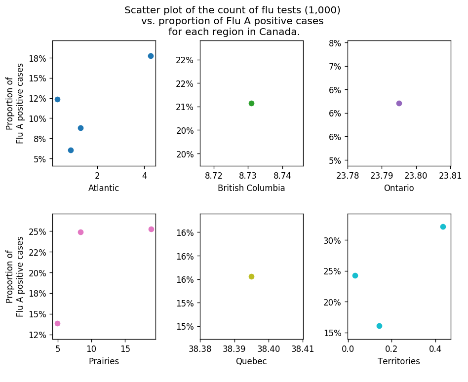

```python
# code for question 2 (b)
import numpy as np
# Visualization 2: draw multiple scatter
# plots of proportion of Flu A positive
# vs. the number tested, one for each region

# adjust plot size
fig = plt.figure(
    figsize=(8, 6),
    dpi=120
)
# use a color map
# https://matplotlib.org/examples/color/colormaps_reference.html
color_map = plt.cm.get_cmap('tab10', 6)

loc = 231
for ind, (reg, dat) in enumerate(fludat1.groupby('region')):
    ax = plt.subplot(loc + ind)
    plt.scatter(
        dat['Flu Tested']/1000,
        dat['propfluA'],
        label=reg,
        c=np.array(color_map(ind), ndmin=2)
    );
    # label axes
    plt.xlabel(reg + '\n')
    if (ind == 0 or ind == 3):
        plt.ylabel('Proportion of\nFlu A positive cases')
    # format y axis
    ax.yaxis.set_major_formatter(
        FuncFormatter(lambda y, _: '{:.0%}'.format(y))
    )

# set plot title
plt.suptitle(
    'Scatter plot of the count of flu tests (1,000) \n' +
    'vs. proportion of Flu A positive cases \n' +
    'for each region in Canada.'
, va='bottom')
# fit plot to avoid overlapping labels
plt.tight_layout();
```

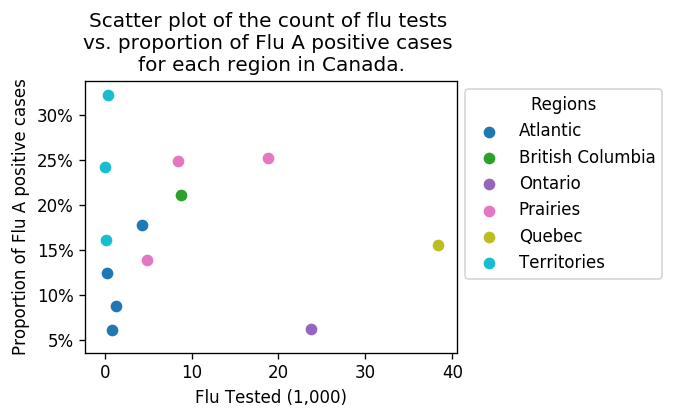

```python
# Visualization 1: draw a single scatter
# plot of proportion of Flu A positive
# vs. the number tested with regions color coded

# adjust plot size
fig = plt.figure(
    figsize=(4, 3),
    dpi=120
)
for ind, (reg, dat) in enumerate(fludat1.groupby('region')):
    plt.scatter(
        dat['Flu Tested']/1000,
        dat['propfluA'],
        label=reg,
        c=np.array(color_map(ind), ndmin=2)
    );
# label axes
plt.xlabel('Flu Tested (1,000)')
plt.ylabel('Proportion of Flu A positive cases')
# format y axis
fig.get_axes()[0].yaxis.set_major_formatter(
    FuncFormatter(lambda y, _: '{:.0%}'.format(y))
)
# set plot title
plt.title(
    'Scatter plot of the count of flu tests \n' +
    'vs. proportion of Flu A positive cases \n' +
    'for each region in Canada.'
)
# place plot legend
plt.legend(
    title='Regions',
    loc='upper left',
    bbox_to_anchor=(1., 1.),
    ncol=1
);
```

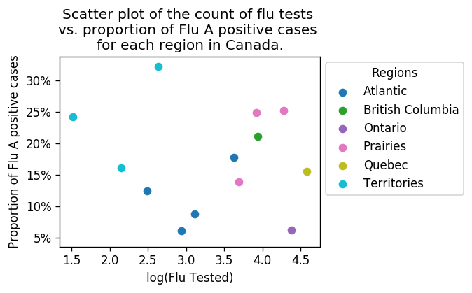

```python
# Adopted from a student's answer
# Visualization 3: draw a single scatter
# plot of proportion of Flu A positive
# vs. the number tested on a log scale
# with regions color coded

# adjust plot size
fig = plt.figure(
    figsize=(4, 3),
    dpi=120
)
# use a color map
# https://matplotlib.org/examples/color/colormaps_reference.html
color_map = plt.cm.get_cmap('tab10', 6)
for ind, (reg, dat) in enumerate(fludat1.groupby('region')):
    plt.scatter(
        np.log10(dat['Flu Tested']),
        dat['propfluA'],
        label=reg,
        c=np.array(color_map(ind), ndmin=2)
    );
# label axes
plt.xlabel('log(Flu Tested)')
plt.ylabel('Proportion of Flu A positive cases')
# format y axis
fig.get_axes()[0].yaxis.set_major_formatter(
    FuncFormatter(lambda y, _: '{:.0%}'.format(y))
)
# set plot title
plt.title(
    'Scatter plot of the count of flu tests \n' +
    'vs. proportion of Flu A positive cases \n' +
    'for each region in Canada.'
)
# place plot legend
plt.legend(
    title='Regions',
    loc='upper left',
    bbox_to_anchor=(1., 1.),
    ncol=1
);
```

# Answer for Question 2 (b)

- Quebec and Ontario have the largest number of tests (naturally, as they have the largest populations).
- Prairies and Territories have relatively higher proportion of positive Flu A cases.
- ...
- Preference: 3 ~ 2 over 1

# Question 3

> In August 2010, the World Health Organization declared the pandemic over. Since that time, scientists have changed the way they name viruses. The H1N1 virus is now known as H1N1v. The v stands for variant and indicates that the virus normally circulates in animals but has been detected in humans. Since 2011, another strain, H3N2v, has been circulating in humans and also causes the flu. Both strains are included in the flu vaccine for 2018-19. ([see Mayo Clinic Swine Flu](https://www.mayoclinic.org/diseases-conditions/swine-flu/symptoms-causes/syc-20378103))

The dataframe in Question 1(b)(iii) contains data on the subtype of influenza A: H1N1; H3N2; and unsubtyped (i.e., neither H1N1 or H3N2). Is the distribution of influenza A subtype the same in each province and territory?

(a) Create two dataframes that display the distribution of influenza subtype for each province and territory:

(i) The first dataframe should contain the counts of the numbers of positive cases for each subtype. (ii) The second dataframe should contain the proportion of cases for each subtype within each province and territory.

Does the distribution of subtype of influenza A differ by province/territory? Explain.

```python
# dataframe of counts
fluA_count = fludat1[
    fludat1.sort_values('region').columns[[0,2,3,4]]
]
fluA_count.columns = [
    'prov', 'H1N1', 'H3N2', 'Unsubtyped'
]
display(fluA_count)
# dataframe of proportions
fluA_prop = fluA_count.set_index('prov').apply(
    lambda x: x/x.sum(),axis=1
).reset_index()
display(fluA_prop.round(3))
```

|  | prov | H1N1 | H3N2 | Unsubtyped |
| --- | --- | --- | --- | --- |
| 0 | Newfoundland | 1.0 | 0.0 | 113.0 |
| 1 | Prince Edward Island | 38.0 | 0.0 | 0.0 |
| 2 | Nova Scotia | 0.0 | 0.0 | 52.0 |
| 3 | New Brunswick | 42.0 | 1.0 | 715.0 |
| 4 | Quebec | 0.0 | 0.0 | 5974.0 |
| 5 | Ontario | 752.0 | 180.0 | 546.0 |
| 6 | Manitoba | 192.0 | 3.0 | 486.0 |
| 7 | Saskatchewan | 1280.0 | 60.0 | 749.0 |
| 8 | Alberta | 3132.0 | 73.0 | 1540.0 |
| 9 | British Columbia | 1010.0 | 75.0 | 755.0 |
| 10 | Yukon | 16.0 | 1.0 | 6.0 |
| 11 | Northwest Territories | 138.0 | 2.0 | 0.0 |
| 12 | Nunavut | 8.0 | 0.0 | 0.0 |

|  | prov | H1N1 | H3N2 | Unsubtyped |
| --- | --- | --- | --- | --- |
| 0 | Newfoundland | 0.009 | 0.000 | 0.991 |
| 1 | Prince Edward Island | 1.000 | 0.000 | 0.000 |
| 2 | Nova Scotia | 0.000 | 0.000 | 1.000 |
| 3 | New Brunswick | 0.055 | 0.001 | 0.943 |
| 4 | Quebec | 0.000 | 0.000 | 1.000 |
| 5 | Ontario | 0.509 | 0.122 | 0.369 |
| 6 | Manitoba | 0.282 | 0.004 | 0.714 |
| 7 | Saskatchewan | 0.613 | 0.029 | 0.359 |
| 8 | Alberta | 0.660 | 0.015 | 0.325 |
| 9 | British Columbia | 0.549 | 0.041 | 0.410 |
| 10 | Yukon | 0.696 | 0.043 | 0.261 |
| 11 | Northwest Territories | 0.986 | 0.014 | 0.000 |
| 12 | Nunavut | 1.000 | 0.000 | 0.000 |

(b) Write Python code to calculate the proportion of postive cases in all provinces/territories that are H1N1, H3N2, and unsubtyped?

```python
total = fluA_count.iloc[:,1:].sum(axis=0)
(total/total.sum()).round(3)
```

```
H1N1          0.368
H3N2          0.022
Unsubtyped    0.610
dtype: float64
```

(c) If the distribution of influenza A subtype is independent of province/territory then we would expect the proportion of each influenza A subtype within each province/territory to be the same as the proportion of influenza A subtype in the entire sample. Create an appropriate plot to investigate if influenza A and province/territory are independent. Is there evidence that influenza A and province/territory are independent? Briefly explain.

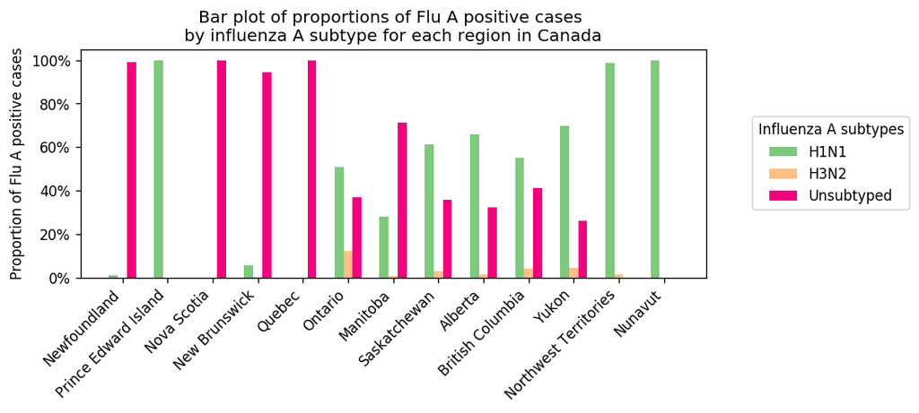

```python
# adjust plot size
fig = plt.figure(
    figsize=(8, 3),
    dpi=120
)
# draw bar plot with provinces in x axis
# proportions in y axis and subtypes placed side by side
# https://stackoverflow.com/questions/10369681/
#  how-to-plot-bar-graphs-with-same-x-coordinates-side-by-side-dodged
color_map = plt.cm.get_cmap('Accent', 4)
width = 0.2
ax = plt.subplot()
for ind, col in enumerate(fluA_prop.select_dtypes('float')):
    ax.bar(
        fluA_prop.index + ind*width,
        fluA_prop[col],
        width=width,
        label=col,
        color=np.array(color_map(ind), ndmin=2)
    );
# label provinces
ax.set_xticks(
    fluA_prop.index + (width)
)
ax.set_xticklabels(
    fluA_prop['prov'],
    rotation=45,
    ha='right'
)
# label axes
plt.ylabel('Proportion of Flu A positive cases')
# format y axis
ax.yaxis.set_major_formatter(
    FuncFormatter(lambda y, _: '{:.0%}'.format(y))
)
# set plot title
plt.title(
    'Bar plot of proportions of Flu A positive cases \n' +
    'by influenza A subtype for each region in Canada'
)
# place plot legend
plt.legend(
    title='Influenza A subtypes',
    loc='center',
    bbox_to_anchor=(1.2, 0.5),
    ncol=1
);
```

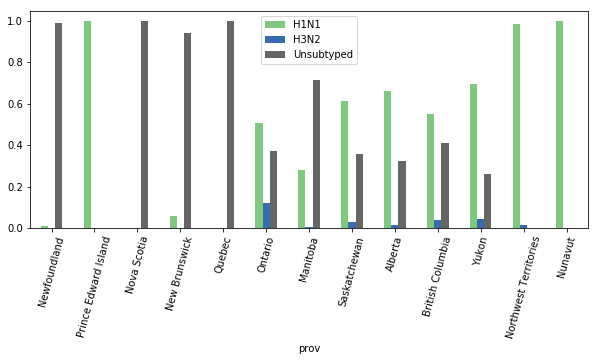

```python
# using pandas function
fluA_prop.plot.bar(
    x = 'prov',
    rot=75,
    figsize=(10, 4),
    colormap='Accent'
);
```

# Answer for Question 3 (c)

Inspection of the figure shows that the distribution of influenza A subtype depends on the province/territory. For example, Nunavut has no cases of H3N2 while 12% of Ontario's positive cases were H3N2.

# Question 4

A formal statistical test of independence for two categorical variables is called the chi-square test of independence. The main implementation of this test in Python is in [sciy.stats](https://docs.scipy.org/doc/scipy/reference/generated/scipy.stats.chi2_contingency.html#scipy.stats.chi2_contingency), and the references therein provide explanations of this test. Another good reference for the chi-square test of independence is available in section 3.3 of [Intro Stat with Randomization and Simulation](https://www.openintro.org/stat/textbook.php?stat_book=isrs).

We will study statistical testing later in the course, but for now use the resources above or other resources, to answer the following questions.

(a) Create a contingency table of region and influenza A subtype.

(b) Create a table that displays the conditional distribution of influenza A subtype given region.

(c) Use the `chi2_contingency` function to compute the chi-square test statistic and expected frequencies for testing if region is independent of influenza A subtype.

(d) Describe in words the the null and alternative hypotheses being tested.

(e) What is the p-value of test? Is the p-value calculated using `chi2_contingency` valid? What do you conclude about the relationship between region of Canada and subtype of influenza.

```python
# code for question 4 (a)
from scipy.stats import chi2_contingency
import numpy as np

#chi2_contingency(fluAdist[['A(H1N1)pdm09 Positive', 'A(H3) Positive', 'A(UnS) Positive']])

region_tab = fludat1[[
    'A(H1N1)pdm09 Positive', 'A(H3) Positive', 'A(UnS) Positive', 'region'
]].groupby('region').sum()
region_tab.astype('int')
```

| region | A(H1N1)pdm09 Positive | A(H3) Positive | A(UnS) Positive |
| --- | --- | --- | --- |
| Atlantic | 81 | 1 | 880 |
| British Columbia | 1010 | 75 | 755 |
| Ontario | 752 | 180 | 546 |
| Prairies | 4604 | 136 | 2775 |
| Quebec | 0 | 0 | 5974 |
| Territories | 162 | 3 | 6 |

```python
# code for question 4 (b)
region_dist = region_tab.apply(
    lambda x: x/region_tab.sum(axis = 1),
    axis = 0
)
region_dist.round(4)
```

| region | A(H1N1)pdm09 Positive | A(H3) Positive | A(UnS) Positive |
| --- | --- | --- | --- |
| Atlantic | 0.0842 | 0.0010 | 0.9148 |
| British Columbia | 0.5489 | 0.0408 | 0.4103 |
| Ontario | 0.5088 | 0.1218 | 0.3694 |
| Prairies | 0.6126 | 0.0181 | 0.3693 |
| Quebec | 0.0000 | 0.0000 | 1.0000 |
| Territories | 0.9474 | 0.0175 | 0.0351 |

```python
# code for question 4 (c)
test, p, df, expect = chi2_contingency(region_tab)
expect = pd.DataFrame(
    expect,
    columns=region_tab.columns,
    index=region_tab.index
)
print(
    'The p-value is:', p,
    '\n\n' +
    'The expected counts are: \n'
)
display(expect.round(0).astype('int'))
```

```
The p-value is: 0.0

The expected counts are:
```

| region | A(H1N1)pdm09 Positive | A(H3) Positive | A(UnS) Positive |
| --- | --- | --- | --- |
| Atlantic | 354 | 21 | 586 |
| British Columbia | 678 | 41 | 1122 |
| Ontario | 544 | 33 | 901 |
| Prairies | 2768 | 165 | 4581 |
| Quebec | 2201 | 132 | 3642 |
| Territories | 63 | 4 | 104 |

```python
# code for question 3 (e)
print('The p-value is:', p)
```

```
The p-value is: 0.0
```

# Answer for Question 4

**d)** The null hypothesis ($H_0$) is that the proportions of influenza A subtypes are independent of provinces and territories and thus all provinces and territories expect equal proportions. The alternative hypothesis ($H_1$) is that the proportions are not independent of the provinces and territories and thus the expected frequencies differ by provinces and territories.

**e)** The p-value is $0.0<0.05$ and thus the null hypothesis is rejected. We can conclude that the the proportions are note independent of the provinces and territories at $95%$ confidence level.

#### Notes on validity of the test:

- The provinces are probably not independent to begin with. Neighbouring provinces/territories are probably more likely to show more similarities compared to regions that are far apart due to climate, terrain, etc.
- From the [`chi2_contingency` documentation](https://docs.scipy.org/doc/scipy-0.15.1/reference/generated/scipy.stats.chi2_contingency.html),

  > An often quoted guideline for the validity of this calculation is that the test should be used only if the observed and expected frequency in each cell is at least 5.